# What makes a YouTube Video Trend?

*By Justin Chen and Evan McIntire*

Youtube is one of the most visited websites in the world, with over 30 million visiters per day, and 5 billion videos watched a day. Youtube showcases videos that are currently popular on their [Trending videos page](https://www.youtube.com/feed/trending). From the perspective of a content creator, having a trending video is considered an accomplishment, and can bring a lot of revenue and attention. Advertisers also like trending videos and will often pay more to have their ads shown in hopes of reaching a wider audience.

There are a lot of other, independent forces and trends that affect how popular Youtube videos will become. However, due to given such as tags, categories, and collected data such as views and likes, we can attempt to quantify what constitutes a trending video from a data science perspective. This type of data is not only interesting to examine and interpret, but can be very valuable to advertisers.

Using a dataset that contains the trending videos from November 2017 to June 2018, as well as category metadata, can we discren any factors that these videos have in common, and then use that to try to predict how succesful other videos will be, and what level of engagement they will get?

## Getting Started

We'll be using Python 3 with libraries such as pandas, numpy, matplotlib, scikit-learn, and seaborn to do this analysis.

```python
# Imports
import pandas as pd
import numpy as np
import matplotlib as plt
import json
import seaborn as sns
from datetime import datetime
from sklearn.linear_model import LinearRegression
import statsmodels.api as sm
import warnings
import operator

# Disable warnings
warnings.filterwarnings('ignore')

# Use seaborn
sns.set()
```

# Preprocessing our Data

Before running any actual code, we had to change our US_category_id.json file so it would properly read into pandas.

# Reading the Data

First, we'll load the category data.

```python
category_df = pd.read_json("youtube-new/US_category_id.json")
category_df.head()
```

|  | etag | id | kind | snippet |
| --- | --- | --- | --- | --- |
| 0 | "m2yskBQFythfE4irbTIeOgYYfBU/Xy1mB4_yLrHy_BmKm... | 1 | youtube#videoCategory | {'channelId': 'UCBR8-60-B28hp2BmDPdntcQ', 'tit... |
| 1 | "m2yskBQFythfE4irbTIeOgYYfBU/UZ1oLIIz2dxIhO45Z... | 2 | youtube#videoCategory | {'channelId': 'UCBR8-60-B28hp2BmDPdntcQ', 'tit... |
| 2 | "m2yskBQFythfE4irbTIeOgYYfBU/nqRIq97-xe5XRZTxb... | 10 | youtube#videoCategory | {'channelId': 'UCBR8-60-B28hp2BmDPdntcQ', 'tit... |
| 3 | "m2yskBQFythfE4irbTIeOgYYfBU/HwXKamM1Q20q9BN-o... | 15 | youtube#videoCategory | {'channelId': 'UCBR8-60-B28hp2BmDPdntcQ', 'tit... |
| 4 | "m2yskBQFythfE4irbTIeOgYYfBU/9GQMSRjrZdHeb1OEM... | 17 | youtube#videoCategory | {'channelId': 'UCBR8-60-B28hp2BmDPdntcQ', 'tit... |

We have a total of 4 columns from our category data.

- etag - Some unique identifier for each specific category
- id - The idea for an associated category
- kind - The type of category
- snippet - An object that contains information such as the channel ID and title of a category.

Now, we'll load the main dataset. Luckily, pandas makes it really easy to import from a CSV!

```python
yt_df = pd.read_csv("youtube-new/USvideos.csv")
yt_df.tail()
```

|  | video_id | trending_date | title | channel_title | category_id | publish_time | tags | views | likes | dislikes | comment_count | thumbnail_link | comments_disabled | ratings_disabled | video_error_or_removed | description |
| --- | --- | --- | --- | --- | --- | --- | --- | --- | --- | --- | --- | --- | --- | --- | --- | --- |
| 40944 | BZt0qjTWNhw | 18.14.06 | The Cat Who Caught the Laser | AaronsAnimals | 15 | 2018-05-18T13:00:04.000Z | aarons animals\|"aarons"\|"animals"\|"cat"\|"cats"... | 1685609 | 38160 | 1385 | 2657 | https://i.ytimg.com/vi/BZt0qjTWNhw/default.jpg | False | False | False | The Cat Who Caught the Laser - Aaron's Animals |
| 40945 | 1h7KV2sjUWY | 18.14.06 | True Facts : Ant Mutualism | zefrank1 | 22 | 2018-05-18T01:00:06.000Z | [none] | 1064798 | 60008 | 382 | 3936 | https://i.ytimg.com/vi/1h7KV2sjUWY/default.jpg | False | False | False | NaN |
| 40946 | D6Oy4LfoqsU | 18.14.06 | I GAVE SAFIYA NYGAARD A PERFECT HAIR MAKEOVER ... | Brad Mondo | 24 | 2018-05-18T17:34:22.000Z | I gave safiya nygaard a perfect hair makeover ... | 1066451 | 48068 | 1032 | 3992 | https://i.ytimg.com/vi/D6Oy4LfoqsU/default.jpg | False | False | False | I had so much fun transforming Safiyas hair in... |
| 40947 | oV0zkMe1K8s | 18.14.06 | How Black Panther Should Have Ended | How It Should Have Ended | 1 | 2018-05-17T17:00:04.000Z | Black Panther\|"HISHE"\|"Marvel"\|"Infinity War"\|... | 5660813 | 192957 | 2846 | 13088 | https://i.ytimg.com/vi/oV0zkMe1K8s/default.jpg | False | False | False | How Black Panther Should Have EndedWatch More ... |
| 40948 | ooyjaVdt-jA | 18.14.06 | Official Call of Duty®: Black Ops 4 — Multipla... | Call of Duty | 20 | 2018-05-17T17:09:38.000Z | call of duty\|"cod"\|"activision"\|"Black Ops 4" | 10306119 | 357079 | 212976 | 144795 | https://i.ytimg.com/vi/ooyjaVdt-jA/default.jpg | False | False | False | Call of Duty: Black Ops 4 Multiplayer raises t... |

We can see our dataset has a lot of columns:

- video_id
- trending_date
- title
- channel_title
- category_id
- publish_time
- tags
- views
- likes
- dislikes
- comment_count
- thumbnail_link
- comments_disabled
- ratings_disabled
- video_error_or_removed
- description

We don't need all of these, and some of them are in formats that aren't that useful for us. Let's fix this!

# Tidying the Data

First, we're going to clean up category data. We only want the id and the title, so we can safely drop everything else.

```python
# Iterate through the dataframe
for index, row in category_df.iterrows():
    # Extract 'title' from 'snippet' object
    category_df.at[index, 'category'] = row['snippet']['title']
# Drop useless columns
category_df = category_df.drop(['kind','etag','snippet'], axis=1)
# Index on the id, and drop the old id col
categorydf = category_df.set_index(category_df.id)
categorydf.drop('id', axis=1)

# Grab it as a dict
categories = categorydf['category']
categories[:5]
```

```
id
1     Film & Animation
2     Autos & Vehicles
10               Music
15      Pets & Animals
17              Sports
Name: category, dtype: object
```

Next, we're going to tidy up the US Trending Youtube Video Dataset.

We also want to convert the `publish_time` and `trending_date` of each row into datetime objects so they're easier to work with later.

In additon, we want `tags` as an array rather than a big string, so we can explore and see if tags have any relationship with trending videos.

```python
for index, row in yt_df.iterrows():
    # Convert trending date and publish time into python datetimes
    yt_df.at[index, 'trending_date'] = datetime.strptime(row['trending_date'], '%y.%d.%m')
    yt_df.at[index, 'publish_datetime'] = datetime.strptime(row['publish_time'].split(".")[0], '%Y-%m-%dT%H:%M:%S')

    # Clean up tags
    yt_df.at[index, 'tags'] = row['tags'].replace('"','').split("|")

    # Attach category
    yt_df.at[index, 'category'] = categories[row['category_id']]

# Drop unwanted cols, and re-order
yt_df = yt_df.drop(['publish_time', 'thumbnail_link', 'comments_disabled', 'ratings_disabled', 'video_error_or_removed','description'], axis=1)
yt_df = yt_df[['video_id', 'title','channel_title','category_id','category','publish_datetime','trending_date','tags','views','likes','dislikes','comment_count']]
yt_df.head()
```

|  | video_id | title | channel_title | category_id | category | publish_datetime | trending_date | tags | views | likes | dislikes | comment_count |
| --- | --- | --- | --- | --- | --- | --- | --- | --- | --- | --- | --- | --- |
| 0 | 2kyS6SvSYSE | WE WANT TO TALK ABOUT OUR MARRIAGE | CaseyNeistat | 22 | People & Blogs | 2017-11-13 17:13:01 | 2017-11-14 00:00:00 | [SHANtell martin] | 748374 | 57527 | 2966 | 15954 |
| 1 | 1ZAPwfrtAFY | The Trump Presidency: Last Week Tonight with J... | LastWeekTonight | 24 | Entertainment | 2017-11-13 07:30:00 | 2017-11-14 00:00:00 | [last week tonight trump presidency, last week... | 2418783 | 97185 | 6146 | 12703 |
| 2 | 5qpjK5DgCt4 | Racist Superman \| Rudy Mancuso, King Bach & Le... | Rudy Mancuso | 23 | Comedy | 2017-11-12 19:05:24 | 2017-11-14 00:00:00 | [racist superman, rudy, mancuso, king, bach, r... | 3191434 | 146033 | 5339 | 8181 |
| 3 | puqaWrEC7tY | Nickelback Lyrics: Real or Fake? | Good Mythical Morning | 24 | Entertainment | 2017-11-13 11:00:04 | 2017-11-14 00:00:00 | [rhett and link, gmm, good mythical morning, r... | 343168 | 10172 | 666 | 2146 |
| 4 | d380meD0W0M | I Dare You: GOING BALD!? | nigahiga | 24 | Entertainment | 2017-11-12 18:01:41 | 2017-11-14 00:00:00 | [ryan, higa, higatv, nigahiga, i dare you, idy... | 2095731 | 132235 | 1989 | 17518 |

# Exploratory Data Analysis

Now that we've cleaned up our dataset, we can start to explore it using matplotlib/seaborn.

## How do people react to trending videos?

First, let's look at views over time. Since Youtube has grown over the years, we would expect that the views that trending videos get also goes up over time.

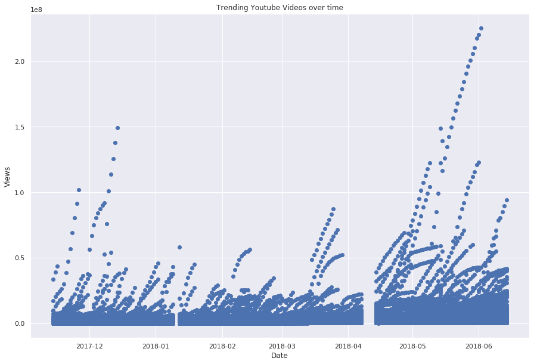

```python
# Convert time to something plottable
dates = plt.dates.date2num(yt_df['trending_date'])

# Plot, metadata
fig, ax = plt.pyplot.subplots(figsize=(15,10))
plt.pyplot.plot_date(dates, yt_df['views'])
ax.set(xlabel='Date', ylabel='Views', title='Trending Youtube Videos over time')

plt.pyplot.show()
```

First, let's find the videos that got over 150,000,000 views.

```python
yt_df[yt_df['views'] > 150000000]
```

|  | video_id | title | channel_title | category_id | category | publish_datetime | trending_date | tags | views | likes | dislikes | comment_count |
| --- | --- | --- | --- | --- | --- | --- | --- | --- | --- | --- | --- | --- |
| 35878 | VYOjWnS4cMY | Childish Gambino - This Is America (Official V... | ChildishGambinoVEVO | 10 | Music | 2018-05-06 04:00:07 | 2018-05-20 00:00:00 | [Childish Gambino, Rap, This Is America, mcDJ ... | 156612892 | 4110879 | 261521 | 437053 |
| 36100 | VYOjWnS4cMY | Childish Gambino - This Is America (Official V... | ChildishGambinoVEVO | 10 | Music | 2018-05-06 04:00:07 | 2018-05-21 00:00:00 | [Childish Gambino, Rap, This Is America, mcDJ ... | 162556776 | 4202645 | 269530 | 446165 |
| 36301 | VYOjWnS4cMY | Childish Gambino - This Is America (Official V... | ChildishGambinoVEVO | 10 | Music | 2018-05-06 04:00:07 | 2018-05-22 00:00:00 | [Childish Gambino, Rap, This Is America, mcDJ ... | 167997997 | 4281819 | 276626 | 453206 |
| 36505 | VYOjWnS4cMY | Childish Gambino - This Is America (Official V... | ChildishGambinoVEVO | 10 | Music | 2018-05-06 04:00:07 | 2018-05-23 00:00:00 | [Childish Gambino, Rap, This Is America, mcDJ ... | 173478072 | 4360121 | 283961 | 460299 |
| 36710 | VYOjWnS4cMY | Childish Gambino - This Is America (Official V... | ChildishGambinoVEVO | 10 | Music | 2018-05-06 04:00:07 | 2018-05-24 00:00:00 | [Childish Gambino, Rap, This Is America, mcDJ ... | 179045286 | 4437175 | 291098 | 466470 |
| 36913 | VYOjWnS4cMY | Childish Gambino - This Is America (Official V... | ChildishGambinoVEVO | 10 | Music | 2018-05-06 04:00:07 | 2018-05-25 00:00:00 | [Childish Gambino, Rap, This Is America, mcDJ ... | 184446490 | 4512326 | 298157 | 473039 |
| 37123 | VYOjWnS4cMY | Childish Gambino - This Is America (Official V... | ChildishGambinoVEVO | 10 | Music | 2018-05-06 04:00:07 | 2018-05-26 00:00:00 | [Childish Gambino, Rap, This Is America, mcDJ ... | 190950401 | 4594931 | 305435 | 479917 |
| 37333 | VYOjWnS4cMY | Childish Gambino - This Is America (Official V... | ChildishGambinoVEVO | 10 | Music | 2018-05-06 04:00:07 | 2018-05-27 00:00:00 | [Childish Gambino, Rap, This Is America, mcDJ ... | 196222618 | 4656929 | 311042 | 485797 |
| 37531 | VYOjWnS4cMY | Childish Gambino - This Is America (Official V... | ChildishGambinoVEVO | 10 | Music | 2018-05-06 04:00:07 | 2018-05-28 00:00:00 | [Childish Gambino, Rap, This Is America, mcDJ ... | 200820941 | 4714942 | 316129 | 491005 |
| 37730 | VYOjWnS4cMY | Childish Gambino - This Is America (Official V... | ChildishGambinoVEVO | 10 | Music | 2018-05-06 04:00:07 | 2018-05-29 00:00:00 | [Childish Gambino, Rap, This Is America, mcDJ ... | 205643016 | 4776680 | 321493 | 496211 |
| 37935 | VYOjWnS4cMY | Childish Gambino - This Is America (Official V... | ChildishGambinoVEVO | 10 | Music | 2018-05-06 04:00:07 | 2018-05-30 00:00:00 | [Childish Gambino, Rap, This Is America, mcDJ ... | 210338856 | 4836448 | 326902 | 501722 |
| 38146 | VYOjWnS4cMY | Childish Gambino - This Is America (Official V... | ChildishGambinoVEVO | 10 | Music | 2018-05-06 04:00:07 | 2018-05-31 00:00:00 | [Childish Gambino, Rap, This Is America, mcDJ ... | 217750076 | 4934188 | 335462 | 509799 |
| 38345 | VYOjWnS4cMY | Childish Gambino - This Is America (Official V... | ChildishGambinoVEVO | 10 | Music | 2018-05-06 04:00:07 | 2018-06-01 00:00:00 | [Childish Gambino, Rap, This Is America, mcDJ ... | 220490543 | 4962403 | 338105 | 512337 |
| 38547 | VYOjWnS4cMY | Childish Gambino - This Is America (Official V... | ChildishGambinoVEVO | 10 | Music | 2018-05-06 04:00:07 | 2018-06-02 00:00:00 | [Childish Gambino, Rap, This Is America, mcDJ ... | 225211923 | 5023450 | 343541 | 517232 |

As it turns out, it was the same video, just over multiple days! Having duplicates like this could really skew any averages or numerical data, so we can use pandas to remove these duplicates. And while we do that, we can store how many days the video spent trending!

```python
# Number of days trending
days_trending = yt_df.groupby('video_id').size()

# Max views during those days
max_views = yt_df.groupby('video_id')['views'].max()

yt_df = yt_df.drop_duplicates('video_id')
for index, row in yt_df.iterrows():
    yt_df.at[index, 'views'] = max_views[row['video_id']]
    yt_df.at[index, 'days_trending'] = days_trending[row['video_id']]

yt_df.head()
```

|  | video_id | title | channel_title | category_id | category | publish_datetime | trending_date | tags | views | likes | dislikes | comment_count | days_trending |
| --- | --- | --- | --- | --- | --- | --- | --- | --- | --- | --- | --- | --- | --- |
| 0 | 2kyS6SvSYSE | WE WANT TO TALK ABOUT OUR MARRIAGE | CaseyNeistat | 22 | People & Blogs | 2017-11-13 17:13:01 | 2017-11-14 00:00:00 | [SHANtell martin] | 2564903 | 57527 | 2966 | 15954 | 7.0 |
| 1 | 1ZAPwfrtAFY | The Trump Presidency: Last Week Tonight with J... | LastWeekTonight | 24 | Entertainment | 2017-11-13 07:30:00 | 2017-11-14 00:00:00 | [last week tonight trump presidency, last week... | 6109402 | 97185 | 6146 | 12703 | 7.0 |
| 2 | 5qpjK5DgCt4 | Racist Superman \| Rudy Mancuso, King Bach & Le... | Rudy Mancuso | 23 | Comedy | 2017-11-12 19:05:24 | 2017-11-14 00:00:00 | [racist superman, rudy, mancuso, king, bach, r... | 5315471 | 146033 | 5339 | 8181 | 7.0 |
| 3 | puqaWrEC7tY | Nickelback Lyrics: Real or Fake? | Good Mythical Morning | 24 | Entertainment | 2017-11-13 11:00:04 | 2017-11-14 00:00:00 | [rhett and link, gmm, good mythical morning, r... | 913268 | 10172 | 666 | 2146 | 7.0 |
| 4 | d380meD0W0M | I Dare You: GOING BALD!? | nigahiga | 24 | Entertainment | 2017-11-12 18:01:41 | 2017-11-14 00:00:00 | [ryan, higa, higatv, nigahiga, i dare you, idy... | 2819118 | 132235 | 1989 | 17518 | 6.0 |

Let's check for **This is America** again to make sure this transformation works, and then plot again, with the duplicates removed.

```python
yt_df[yt_df['video_id'] == 'VYOjWnS4cMY']
```

|  | video_id | title | channel_title | category_id | category | publish_datetime | trending_date | tags | views | likes | dislikes | comment_count | days_trending |
| --- | --- | --- | --- | --- | --- | --- | --- | --- | --- | --- | --- | --- | --- |
| 33351 | VYOjWnS4cMY | Childish Gambino - This Is America (Official V... | ChildishGambinoVEVO | 10 | Music | 2018-05-06 04:00:07 | 2018-05-08 00:00:00 | [Childish Gambino, Rap, This Is America, mcDJ ... | 225211923 | 1405355 | 51547 | 149473 | 25.0 |

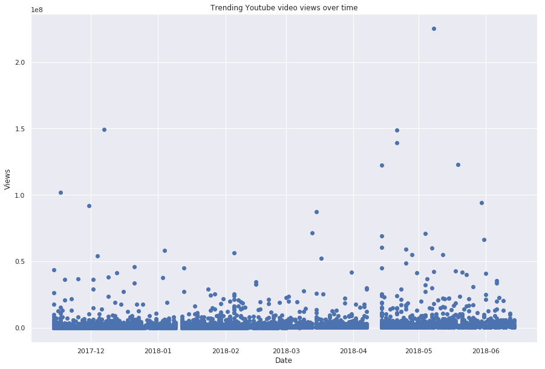

```python
# Convert time to something plottable
dates = plt.dates.date2num(yt_df['trending_date'])

# Plot, metadata
fig, ax = plt.pyplot.subplots(figsize=(15,10))
plt.pyplot.plot_date(dates, yt_df['views'])
ax.set(xlabel='Date', ylabel='Views', title='Trending Youtube video views over time')

plt.pyplot.show()
```

This graph is a little more clean that the last one. Even with the duplicates removed, it's clear that we got more "big hits" in the second half of the dataset, and it appears that there are more videos approaching 25 million views in that same timeframe. It looks like more trending videos are breaking away from the baseline we see at the bottom.

Before moving on, let's also take a look at likes and dislikes over time

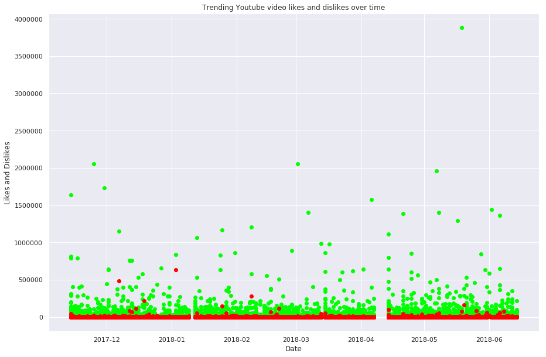

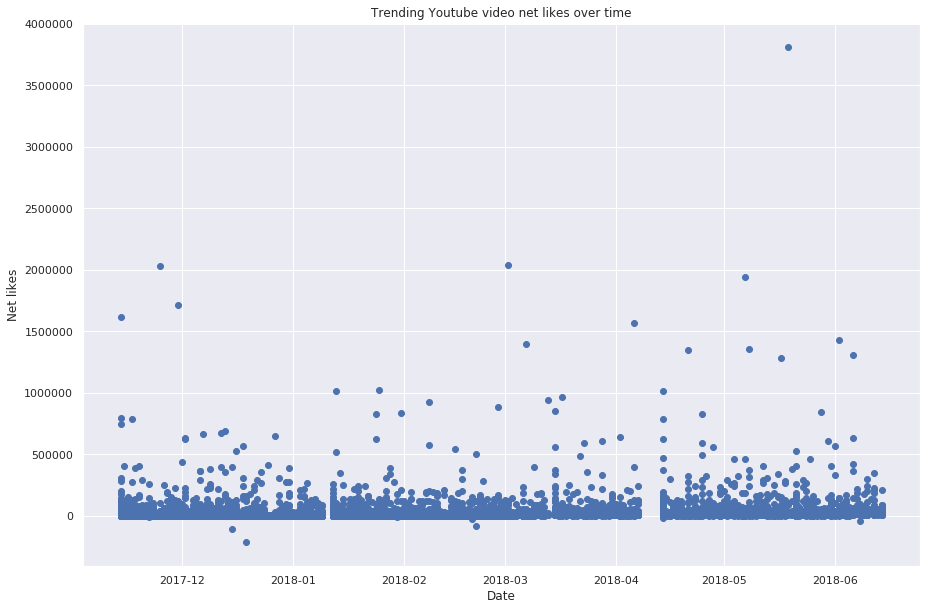

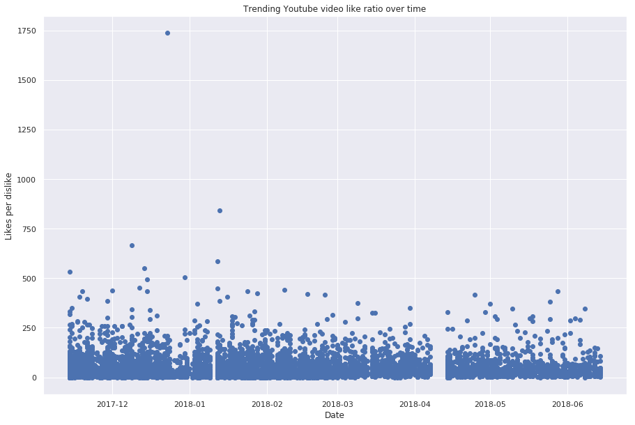

```python
dates = plt.dates.date2num(yt_df['trending_date'])

# Likes and dislikes
fig, ax = plt.pyplot.subplots(figsize=(15,10))
plt.pyplot.plot_date(dates, yt_df['likes'], color="#00ff00")
plt.pyplot.plot_date(dates, yt_df['dislikes'], color="#ff0000")
ax.set(xlabel='Date', ylabel='Likes and Dislikes', title='Trending Youtube video likes and dislikes over time')

plt.pyplot.show()

# Net Likes
fig, ax = plt.pyplot.subplots(figsize=(15,10))
plt.pyplot.plot_date(dates, yt_df['likes'] - yt_df['dislikes'])
ax.set(xlabel='Date', ylabel='Net likes', title='Trending Youtube video net likes over time')

plt.pyplot.show()

# Compute like/dislike ration
for index, row in yt_df.iterrows():
    if row['dislikes'] != 0:
        yt_df.at[index, 'like_ratio'] = int(row['likes']/row['dislikes'])
    else:
        # If we have no dislikes, then we just set it
        yt_df.at[index, 'like_ratio'] = int(row['likes'])

# Ratio
fig, ax = plt.pyplot.subplots(figsize=(15,10))
plt.pyplot.plot_date(dates, yt_df['like_ratio'])
ax.set(xlabel='Date', ylabel='Likes per dislike', title='Trending Youtube video like ratio over time')

plt.pyplot.show()
```

Most of the videos under half a million likes, a and generally under 250,000 net likes. Some videos have a negative amount of net likes (i.e., more dislikes than likes). This shows that not every trending video is positively recieved (as also shwon by this year's Youtube rewind, which is not in the dataset!). We also see that there are usually between 1 to 250 likes per dislike, with the ratio being skewed towards the lower end of the spectrum.

It's also worth noting that even though the numbers are lower, the plot of likes has the same shape as the views graph we examined earlier.

Here are the videos with negative net likes:

```python
yt_df[yt_df['likes'] < yt_df['dislikes']]
```

|  | video_id | title | channel_title | category_id | category | publish_datetime | trending_date | tags | views | likes | dislikes | comment_count | days_trending | like_ratio |
| --- | --- | --- | --- | --- | --- | --- | --- | --- | --- | --- | --- | --- | --- | --- |
| 43 | 0tO_l_Ed5Rs | Matthew Santoro - FACTS (Official Music Video)... | MatthewSantoro | 10 | Music | 2017-11-11 16:00:01 | 2017-11-14 00:00:00 | [matthew santoro facts, music video, matthew s... | 393265 | 15186 | 15448 | 7484 | 4.0 | 0.0 |
| 47 | sbcbvuitiTc | Stephon Marbury and Jimmer Fredette fight in C... | NBA Highlights · YouTube | 17 | Sports | 2017-11-10 18:23:05 | 2017-11-14 00:00:00 | [NBA, Basketball, Sports] | 1015189 | 2017 | 2425 | 1447 | 2.0 | 0.0 |
| 75 | k8NxqyGcZA4 | Rosie O’Donnell On Donald Trump’s Hostility To... | Watch What Happens Live with Andy Cohen | 24 | Entertainment | 2017-11-10 12:59:55 | 2017-11-14 00:00:00 | [What What Happens live, reality, interview, f... | 277614 | 2429 | 5381 | 2325 | 4.0 | 0.0 |
| 133 | X7flefV8tec | President Bill Clinton On Dictators, Democracy... | Team Coco | 24 | Entertainment | 2017-11-09 02:37:49 | 2017-11-14 00:00:00 | [[none]] | 379918 | 4364 | 4448 | 1997 | 2.0 | 0.0 |
| 169 | bhoFXkVy8JA | Basmati Blues - Trailer | Blockbuster | 1 | Film & Animation | 2017-10-13 08:20:03 | 2017-11-14 00:00:00 | [Blockbuster, blockbuster.dk, blockbuster.se, ... | 12609 | 40 | 79 | 17 | 1.0 | 0.0 |
| 195 | u7pV4vxD1bs | World's first self-driving shuttle crashes on ... | KSNV News 3 Las Vegas | 25 | News & Politics | 2017-11-08 20:16:47 | 2017-11-14 00:00:00 | [Technology, self-driving car, Las Vegas, News] | 169511 | 57 | 59 | 79 | 1.0 | 0.0 |
| 295 | VJlSq6h0LNg | HOL HD: Mike Riley Monday Press Conference | Gregg Peterson | 17 | Sports | 2017-11-13 18:41:18 | 2017-11-15 00:00:00 | [HuskerOnline.com, Nebraska Football, Huskers,... | 6993 | 18 | 57 | 54 | 3.0 | 0.0 |
| 307 | 1WDj0DddCcM | WATCH: Sen. Mitch McConnell on tax reform | WLKY News Louisville | 25 | News & Politics | 2017-11-13 16:14:00 | 2017-11-15 00:00:00 | [[none]] | 6801 | 11 | 35 | 18 | 3.0 | 0.0 |
| 446 | upEIZAihcwo | Devin Booker has words with Lakers assistant J... | NBA Highlights · YouTube | 17 | Sports | 2017-11-15 17:29:26 | 2017-11-16 00:00:00 | [NBA, Basketball, Sports, Los Angeles Lakers, ... | 20541 | 7 | 42 | 10 | 5.0 | 0.0 |
| 1247 | wuEKwkTqdw4 | LaToya Cantrell elected mayor of New Orleans | NOLA.com | 25 | News & Politics | 2017-11-19 05:07:23 | 2017-11-20 00:00:00 | [new orleans videos] | 25203 | 193 | 238 | 390 | 7.0 | 0.0 |
| 1422 | vNya04dlC4I | Highlights from the 2017 American Music Awards | Washington Post | 24 | Entertainment | 2017-11-20 15:38:58 | 2017-11-21 00:00:00 | [AMA Awards, American Music Awards, Diana Rose... | 62644 | 114 | 156 | 138 | 7.0 | 0.0 |
| 1490 | A_mlvG_nRsg | Kelly Oubre Punches John Wall in the Lead duri... | Rob Andretti | 17 | Sports | 2017-10-28 11:15:14 | 2017-11-21 00:00:00 | [[none]] | 2447 | 0 | 2 | 0 | 2.0 | 0.0 |
| 1757 | pi0ePRY7TSc | Terry Crews Says He Was Sexually Assaulted | Wendy Williams | 24 | Entertainment | 2017-11-16 02:00:03 | 2017-11-22 00:00:00 | [terry crews, good morning america, mariah car... | 451381 | 3110 | 14575 | 3095 | 1.0 | 0.0 |
| 2644 | 5WUDfviiKRE | 二贵摔跤 - tienghoa.net | Tina Nguyen | 27 | Education | 2011-03-01 04:14:08 | 2017-11-27 00:00:00 | [hanyuqiao] | 22695 | 93 | 275 | 172 | 5.0 | 0.0 |
| 3012 | NqntFonA2iY | Jennifer Lawrence: 'I Become Incredibly Rude' ... | Variety | 24 | Entertainment | 2017-11-28 19:26:57 | 2017-11-29 00:00:00 | [Variety, Variety Studio, Actors on Actors, Je... | 657337 | 697 | 1479 | 703 | 7.0 | 0.0 |
| 3948 | NyNtWpDnT0Y | Peter Bone to Trump: Delete Your Account | Ross Kempsell | 23 | Comedy | 2017-11-30 11:40:37 | 2017-12-03 00:00:00 | [[none]] | 3052 | 6 | 39 | 0 | 2.0 | 0.0 |
| 4216 | hRAGY4BaFQs | Xscape's Tamika Scott Falls During Epic Wardro... | TMZ | 24 | Entertainment | 2017-12-04 20:02:25 | 2017-12-05 00:00:00 | [TMZ2016FS11221, TMZ, Hollywood, Celebrity, En... | 198195 | 327 | 436 | 184 | 7.0 | 0.0 |
| 4351 | HVjlcUtuENM | Our Surrogate Story: The Truth \| Gigi | Gigi Gorgeous | 26 | Howto & Style | 2017-11-29 00:53:50 | 2017-12-05 00:00:00 | [gigi, gigigorgeous, gregory, gorgeous, gregor... | 778338 | 18096 | 21877 | 4477 | 2.0 | 0.0 |
| 4418 | 0ZAA9Y4F37I | Veteran Congressman John Conyers Announces He ... | The View | 25 | News & Politics | 2017-12-05 16:12:12 | 2017-12-06 00:00:00 | [John Conyers, congress, the view, hot topics,... | 52395 | 243 | 271 | 249 | 6.0 | 0.0 |
| 4449 | Cfn25A6krNg | Trump Dismantles Bears Ears National Monument | The New York Times | 25 | News & Politics | 2017-12-05 01:00:00 | 2017-12-06 00:00:00 | [The New York Times, NY Times, NYT, Times Vide... | 28378 | 211 | 463 | 633 | 1.0 | 0.0 |
| 5038 | 5Ad2pIlg3Dk | Lindsey Vonn: I won't be representing Trump at... | CNN | 25 | News & Politics | 2017-12-07 13:31:27 | 2017-12-09 00:00:00 | [latest News, Happening Now, CNN, President Tr... | 216743 | 2112 | 3224 | 4876 | 5.0 | 0.0 |
| 5618 | N4LQuwSjc34 | WATCH: Trump sexual misconduct accusers hold n... | PBS NewsHour | 25 | News & Politics | 2017-12-11 16:11:28 | 2017-12-12 00:00:00 | [Donald Trump, sexual misconduct] | 57770 | 625 | 792 | 0 | 2.0 | 0.0 |
| 5643 | 30UjfElERlc | Panel Of Women Who Have Accused President Trum... | TIME | 25 | News & Politics | 2017-12-11 18:17:36 | 2017-12-12 00:00:00 | [trump sexual harassment, sexual harassment, t... | 6450 | 39 | 43 | 39 | 5.0 | 0.0 |
| 5805 | lYEj9snU838 | Boy speaks out on viral bullying video, mom ad... | CBS This Morning | 25 | News & Politics | 2017-12-12 12:58:41 | 2017-12-13 00:00:00 | [video, cbs, news, Keaton Jones, Tennessee, Fa... | 1363711 | 2306 | 4508 | 3766 | 7.0 | 0.0 |
| 5828 | MyAnv1nY5Vw | Keaton Jones, 11: I Hope My Viral Anti-Bullyin... | TODAY | 25 | News & Politics | 2017-12-12 15:07:05 | 2017-12-13 00:00:00 | [The TODAY Show, TODAY Show, TODAY, NBC, NBC N... | 72365 | 312 | 542 | 91 | 6.0 | 0.0 |
| 6005 | 8I_NkJ8VTEI | Judge Roy Moore Campaign Statement | Roy Moore for Senate | 22 | People & Blogs | 2017-12-14 03:04:05 | 2017-12-14 00:00:00 | [[none]] | 789818 | 441 | 4693 | 0 | 8.0 | 0.0 |
| 6026 | tT-lTxhW7pY | Roy Moore Delivers Concession Speech From Alab... | NBC News | 25 | News & Politics | 2017-12-13 04:37:41 | 2017-12-14 00:00:00 | [nbc news, breaking news, us news, politics, c... | 201025 | 537 | 4074 | 0 | 6.0 | 0.0 |
| 6201 | 8d_202l55LU | The FCC repeals its net neutrality rules | Washington Post | 25 | News & Politics | 2017-12-14 18:49:06 | 2017-12-15 00:00:00 | [fcc net neutrality, breaking news video, vide... | 1263104 | 4870 | 110707 | 19843 | 4.0 | 0.0 |
| 6259 | FY8T06A-j_c | Top 10 Plays of the Night: December 13, 2017 | NBA | 17 | Sports | 2017-12-14 07:20:36 | 2017-12-15 00:00:00 | [nba, highlights, basketball, plays, amazing, ... | 211419 | 2639 | 3785 | 341 | 2.0 | 0.0 |
| 7034 | csqXekWeBYo | Dan Le Batard Breaks Down On Air After John Sk... | Sports Lovers n1 | 22 | People & Blogs | 2017-12-18 19:02:21 | 2017-12-19 00:00:00 | [Dan Le Batard, John Skipper, Media News, Media] | 35916 | 43 | 55 | 0 | 5.0 | 0.0 |
| ... | ... | ... | ... | ... | ... | ... | ... | ... | ... | ... | ... | ... | ... | ... |
| 16194 | C-rumHvmqCA | T-Mobile \| #LittleOnes \| 2018 Big Game Ad | T-Mobile | 24 | Entertainment | 2018-02-05 02:12:26 | 2018-02-05 00:00:00 | [best super bowl ads, best superbowl ads, best... | 15045586 | 1700 | 5735 | 0 | 9.0 | 0.0 |
| 16198 | wJJqGh2HLM8 | Hope Detector \| Hyundai NFL Super Bowl LII | HyundaiUSA | 2 | Autos & Vehicles | 2018-02-04 23:31:40 | 2018-02-05 00:00:00 | [Hyundai, Hyundai Super Bowl, Hyundai surprise... | 15904385 | 243 | 600 | 105 | 8.0 | 0.0 |
| 16396 | SlbY1tGARUA | Official Ram Trucks Super Bowl Commercial \| Dr... | Ram Trucks | 2 | Autos & Vehicles | 2018-02-05 00:45:18 | 2018-02-06 00:00:00 | [Built To Serve, Ram Serve, Sunday Service, ML... | 2294097 | 4223 | 9681 | 2959 | 4.0 | 0.0 |
| 16408 | 91Q0kddGWLc | Diet Coke Twisted Mango \| Groove | Diet Coke | 26 | Howto & Style | 2018-02-05 00:10:13 | 2018-02-06 00:00:00 | [diet coke, super bowl, diet coke flavors, twi... | 494907 | 1181 | 3007 | 905 | 8.0 | 0.0 |
| 16443 | s32C3KAi0Nc | How our reporter tracked down the Nazi running... | Chicago Sun-Times | 25 | News & Politics | 2018-02-04 17:54:24 | 2018-02-06 00:00:00 | [Chicago, news, journalism, politics, neo nazi... | 56370 | 238 | 278 | 725 | 6.0 | 0.0 |
| 16804 | jSQj4lq8ZEg | Rep. Nancy Pelosi (D-CA) finds out she's given... | C-SPAN | 25 | News & Politics | 2018-02-07 22:19:24 | 2018-02-08 00:00:00 | [Nancy Pelosi, House of Representatives, C-SPA... | 19422 | 93 | 143 | 109 | 7.0 | 0.0 |
| 16981 | IPgdIHV_zMo | I Feel Pretty Trailer #1 \| Movieclips Trailers | Movieclips Trailers | 1 | Film & Animation | 2018-02-08 20:00:03 | 2018-02-09 00:00:00 | [I Feel Pretty, I Feel Pretty Trailer, I Feel ... | 1071466 | 2972 | 7966 | 1632 | 10.0 | 0.0 |
| 17090 | 0q9Cm11d-fE | Trump wanted a parade. He might get one. | Washington Post | 25 | News & Politics | 2018-02-06 23:07:12 | 2018-02-09 00:00:00 | [trump, parade, bastille day, france, military... | 32336 | 182 | 212 | 1036 | 1.0 | 0.0 |
| 17258 | JdHhNxedKs4 | Does Melania Trump Like Cecily Strong’s SNL Im... | Watch What Happens Live with Andy Cohen | 24 | Entertainment | 2018-02-08 05:57:58 | 2018-02-10 00:00:00 | [What What Happens live, reality, interview, f... | 96835 | 252 | 312 | 93 | 5.0 | 0.0 |
| 17788 | GJjQl1q_jtE | Foudy reports on Mirai Nagasu's historic tripl... | ESPN | 17 | Sports | 2018-02-12 14:02:14 | 2018-02-13 00:00:00 | [espn, espn live, julie, foudy, reports, on, a... | 254142 | 460 | 552 | 100 | 2.0 | 0.0 |
| 18007 | b-5c_Z3pUVk | Andy Cohen Weighs In on Kim Cattrall’s Feud wi... | Radio Andy | 24 | Entertainment | 2018-02-12 17:30:10 | 2018-02-14 00:00:00 | [Andy Cohen, Kim Cattrall, Sarah Jessica Parke... | 48907 | 124 | 207 | 211 | 6.0 | 0.0 |
| 18609 | 3McYSX6jSIg | Ready to Serve \| Romney for Utah | mittromney | 22 | People & Blogs | 2018-02-16 13:21:55 | 2018-02-17 00:00:00 | [[none]] | 99732 | 598 | 840 | 428 | 7.0 | 0.0 |
| 18616 | 2rx8VHNG-DE | Romney announces Utah Senate run | Fox News | 25 | News & Politics | 2018-02-16 14:35:59 | 2018-02-17 00:00:00 | [Fox Friends., Elections, Elections States, Se... | 22871 | 139 | 422 | 288 | 7.0 | 0.0 |
| 18788 | fCuvR9LEczE | Everything You Need to Know About ZOMBIES (Exc... | Just Jared Jr | 24 | Entertainment | 2018-02-17 07:08:38 | 2018-02-18 00:00:00 | [Zombies, Disney Channel, Milo Manheim, Meg Do... | 263464 | 276 | 547 | 198 | 9.0 | 0.0 |
| 18843 | lCT0OaVqIQE | Jeffrey Tambor Fired From 'Transparent' Follow... | CBS Los Angeles | 25 | News & Politics | 2018-02-16 02:26:02 | 2018-02-18 00:00:00 | [CBS 2 News Mid-day, jeffrey tambor, sexual mi... | 1464 | 3 | 15 | 4 | 5.0 | 0.0 |
| 19173 | CMA2iF6RuXk | Fergie's national anthem draws criticism \| ESPN | ESPN | 17 | Sports | 2018-02-19 12:42:36 | 2018-02-20 00:00:00 | [espn, espn live, fergie, national, anthem, dr... | 2762839 | 14362 | 37877 | 21507 | 1.0 | 0.0 |
| 19374 | -hg9t3PdhFE | Confrontation Between Lifeguard, Bodysurfer Ca... | mike m | 22 | People & Blogs | 2018-02-20 16:34:36 | 2018-02-21 00:00:00 | [Fake news david hog] | 102560 | 768 | 1452 | 1232 | 1.0 | 0.0 |
| 19376 | V5cOvyDpWfM | Fergie Performs The U.S. National Anthem / 201... | MLG Highlights | 17 | Sports | 2018-02-19 01:37:11 | 2018-02-21 00:00:00 | [mlg highlights, mlg, basketball, highlights, ... | 21005589 | 32892 | 117128 | 44404 | 7.0 | 0.0 |
| 19397 | oWdLorlbhfU | Tia's Goodbye- Bachelor | Bachelor Nation on ABC | 24 | Entertainment | 2018-02-20 06:00:01 | 2018-02-21 00:00:00 | [the bachelor, the bachelorette, bachelor nati... | 118151 | 176 | 218 | 258 | 8.0 | 0.0 |
| 19406 | Ga7thDlGbs8 | President Trump on bump stocks (C-SPAN) | C-SPAN | 25 | News & Politics | 2018-02-20 21:38:24 | 2018-02-21 00:00:00 | [White House, President of the United States, ... | 41253 | 159 | 295 | 758 | 7.0 | 0.0 |
| 20087 | 4iyOED0DPZw | Host dad who took in accused Florida shooter: ... | CBS This Morning | 25 | News & Politics | 2018-02-20 12:27:48 | 2018-02-24 00:00:00 | [video, cbs, news, Florida school shooting sus... | 40026 | 121 | 128 | 315 | 2.0 | 0.0 |
| 20094 | Q6vfaPuftmE | Donald Trump Jr. Says India's Poorest Have Som... | NBC News | 25 | News & Politics | 2018-02-20 16:55:34 | 2018-02-24 00:00:00 | [NBC, NBC News, Breaking News, US News, World ... | 34284 | 134 | 201 | 263 | 4.0 | 0.0 |
| 20213 | WCKG9J1d5iE | Major bank ends long-time partnership with NRA | Fox Business | 25 | News & Politics | 2018-02-23 16:06:15 | 2018-02-25 00:00:00 | [Cheryl Casone, Tracee Carrasco, Fbn Am, Apple... | 32462 | 349 | 370 | 697 | 8.0 | 0.0 |
| 20581 | OzKmR5BLdbQ | Heather Locklear arrested for domestic violence | Fox News | 25 | News & Politics | 2018-02-26 17:38:19 | 2018-02-27 00:00:00 | [Digital Originals, Fox 411, Wochit, Apple New... | 192417 | 141 | 194 | 360 | 13.0 | 0.0 |
| 21049 | 6xnTeGwRCGY | President Trump set to announce 2020 re-electi... | CBS News | 25 | News & Politics | 2018-02-27 16:19:39 | 2018-03-01 00:00:00 | [President of the United States, Donald Trump,... | 7767 | 63 | 76 | 252 | 6.0 | 0.0 |
| 25957 | hDEc4ImIVHk | Emma Gonzalez gives speech at March for Our Li... | CNN | 25 | News & Politics | 2018-03-24 19:16:38 | 2018-03-26 00:00:00 | [latest News, Happening Now, CNN, us news, pol... | 906941 | 11540 | 12891 | 16387 | 13.0 | 0.0 |
| 28569 | tfREC-AkX20 | Why black Americans are getting less sleep | Vox | 25 | News & Politics | 2018-04-12 13:55:36 | 2018-04-14 00:00:00 | [SleepCycle, sleep, science, vox, Vox.com, exp... | 673554 | 8374 | 25877 | 8280 | 10.0 | 0.0 |
| 28757 | HNvX4pY1TLI | Trump: US, France and UK launch strikes on Syria | CNN | 25 | News & Politics | 2018-04-14 01:26:34 | 2018-04-15 00:00:00 | [latest News, Happening Now, CNN, President Do... | 875577 | 5424 | 5693 | 11213 | 9.0 | 0.0 |
| 36000 | loWpbevW9xg | Charmed \| Extended First Look \| The CW | The CW Television Network | 24 | Entertainment | 2018-05-17 16:01:37 | 2018-05-21 00:00:00 | [The CW, The CW Network, television, shows, TV... | 702374 | 2679 | 4535 | 2014 | 7.0 | 0.0 |
| 39549 | GnGPAYvve1A | #ProudToCreate: Pride 2018 | YouTube Spotlight | 24 | Entertainment | 2018-06-07 19:08:51 | 2018-06-08 00:00:00 | [#Pride, #ProudToCreate, #ProudToBe, #ProudToL... | 1329391 | 29781 | 71617 | 55110 | 7.0 | 0.0 |

101 rows × 14 columns

## What types of videos trend?

Up until now, we've looked at how trending videos are recieved, but haven't looked at the video information itself - tags, category, etc.. As we said before, this is the information that content creators and advertisers want, so they can figure out what type of video trends more, either to make content in that category or advertise more heavily.

To start taking a crack at this, we'll first plot which categories trend the most.

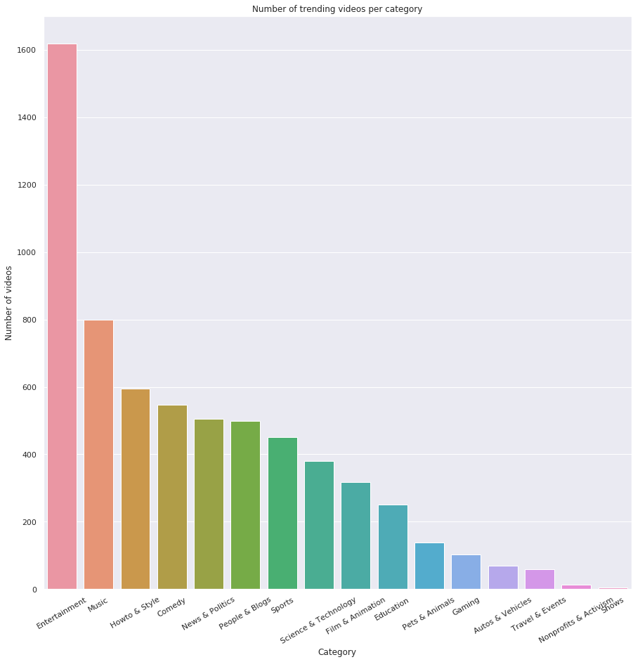

```python
plt.pyplot.figure(figsize=(15,15))
plot = sns.countplot(x='category', data=yt_df, order = yt_df['category'].value_counts().index)
plot.set(title='Number of trending videos per category', xlabel='Category', ylabel='Number of videos')
plot.set_xticklabels(plot.get_xticklabels(), rotation=30);
```

Entertainment is **far and away** the most popular category in trending. If we look at the top 10 viewed items in entertainment in the cell below, we can see that movie trailers are among the most popular. We can tell right away that if an advertiser was interested in volume alone, focusing on entertainment videos would be the most effective.

```python
yt_df[yt_df['category'] == 'Entertainment'].sort_values(by=['views'], ascending=False).head(10)
```

|  | video_id | title | channel_title | category_id | category | publish_datetime | trending_date | tags | views | likes | dislikes | comment_count | days_trending | like_ratio |
| --- | --- | --- | --- | --- | --- | --- | --- | --- | --- | --- | --- | --- | --- | --- |
| 4600 | FlsCjmMhFmw | YouTube Rewind: The Shape of 2017 \| #YouTubeRe... | YouTube Spotlight | 24 | Entertainment | 2017-12-06 17:58:51 | 2017-12-07 00:00:00 | [Rewind, Rewind 2017, youtube rewind 2017, #Yo... | 149376127 | 1149185 | 483924 | 462103 | 8.0 | 2.0 |
| 3200 | 6ZfuNTqbHE8 | Marvel Studios' Avengers: Infinity War Officia... | Marvel Entertainment | 24 | Entertainment | 2017-11-29 13:26:24 | 2017-11-30 00:00:00 | [marvel, comics, comic books, nerdy, geeky, su... | 91933007 | 1735895 | 21969 | 241237 | 9.0 | 79.0 |
| 30750 | u9Mv98Gr5pY | VENOM - Official Trailer (HD) | Sony Pictures Entertainment | 24 | Entertainment | 2018-04-24 03:45:03 | 2018-04-25 00:00:00 | [Venom, Venom Movie, Venom (2018), Marvel, Mar... | 59254638 | 850362 | 26541 | 96767 | 19.0 | 32.0 |
| 24156 | QwievZ1Tx-8 | Marvel Studios' Avengers: Infinity War - Offic... | Marvel Entertainment | 24 | Entertainment | 2018-03-16 13:02:41 | 2018-03-17 00:00:00 | [marvel, comics, comic books, nerd, geek, supe... | 52404970 | 975715 | 9118 | 127045 | 13.0 | 107.0 |
| 30752 | rRr1qiJRsXk | Sanju \| Official Teaser \| Ranbir Kapoor \| Rajk... | FoxStarHindi | 24 | Entertainment | 2018-04-24 07:58:08 | 2018-04-25 00:00:00 | [Sanju Teaser, Official Teaser, Sanju Official... | 48654951 | 511753 | 15606 | 32435 | 18.0 | 32.0 |
| 38161 | 1J76wN0TPI4 | Sanju \| Official Trailer \| Ranbir Kapoor \| Raj... | FoxStarHindi | 24 | Entertainment | 2018-05-30 07:51:32 | 2018-06-01 00:00:00 | [Sanju, Official Trailer, sanju official trail... | 40714581 | 587326 | 18799 | 43728 | 14.0 | 31.0 |
| 5001 | vn9mMeWcgoM | Jurassic World: Fallen Kingdom - Official Trai... | Universal Pictures | 24 | Entertainment | 2017-12-08 01:44:25 | 2017-12-09 00:00:00 | [Jurassic World, Fallen Kingdom, Jurassic Park... | 38070298 | 399200 | 17473 | 58902 | 7.0 | 22.0 |
| 10000 | QwZT7T-TXT0 | So Sorry. | Logan Paul Vlogs | 24 | Entertainment | 2018-01-02 16:42:21 | 2018-01-03 00:00:00 | [logan paul vlog, logan paul, logan, paul, oly... | 37539570 | 835378 | 629120 | 733373 | 7.0 | 1.0 |
| 39349 | g4Hbz2jLxvQ | SPIDER-MAN: INTO THE SPIDER-VERSE - Official T... | Sony Pictures Entertainment | 24 | Entertainment | 2018-06-06 13:00:04 | 2018-06-07 00:00:00 | [Shameik Moore, Hailee Steinfeld, Mahershala A... | 22713067 | 223403 | 6881 | 24311 | 8.0 | 32.0 |
| 34359 | mdWcaWBxxcY | Rita Ora - Girls ft. Cardi B, Bebe Rexha & Cha... | Rita Ora | 24 | Entertainment | 2018-05-11 09:23:16 | 2018-05-13 00:00:00 | [Rita Ora, Rita, Ora, Your Song, Anywhere, Off... | 21888660 | 149643 | 15321 | 14195 | 28.0 | 9.0 |

Movie trailers might get the most views, but are they really representative of all 1600 trending videos in this category? In general? Probably not. Let's look at the overall tags to get a data-oriented view of what kind of video tends to trend.

```python
# Iterate over the data frame and count all tags
tag_counts = {}
for index, row in yt_df.iterrows():
    for s in row['tags']:
        if not s in tag_counts:
            tag_counts[s] = 1
        else:
            tag_counts[s] += 1
# Sort tags by descending
tag_counts = sorted(tag_counts.items(), key=operator.itemgetter(1))
tag_counts.reverse()

# Take only the top 20
tag_counts = tag_counts[0:20]
```

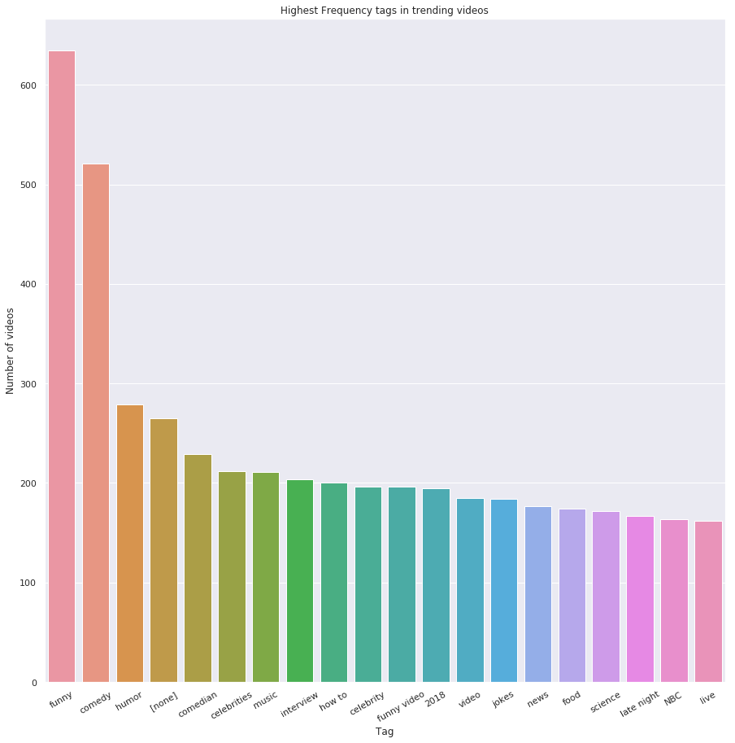

```python
x = []
y = []
for tag in tag_counts:
    x.append(tag[0])
    y.append(tag[1])

plt.pyplot.figure(figsize=(15,15))
plot = sns.barplot(x=x, y=y)
plot.set(title='Highest Frequency tags in trending videos', xlabel='Tag', ylabel='Number of videos')
plot.set_xticklabels(plot.get_xticklabels(), rotation=30);
```

From looking at these tags, we see that videos with "funny" or "comedy" or similar humor-related nouns tend to trend the most. Some amount of it is probably overlap with the same video having many tags, but overall the tags tell us that funny videos make up a lot of what trends.

# User Engagement

As mentioned before, advertisers are a large stakeholder in Youtube, especially when it comes to trending videos.

Content creators encourge users to "like, comment, and subscribe" all the time, because it drives user engagement - things like views, comments, and likes. Advertisers value engagement over raw views, as they tend to lead to higher clickthrough and reach of the ads.

We're going to do analysis to define a reasonable user engagement score, and then use regression to test the following null hypothesis: **There is no relationship between category and engagement**.

## Defining user engagement

Any interaction with the video is considered engagement, but some forms are more rare, and more valuable. Views are the most common, followed by ratings, with comments coming in last place.

As a naive measurement of engagement, we're first going to normalize these metrics against each other, and then score each video as a sum of the normalized metrics.

```python
# Sum metrics using pandas
total_views = yt_df['views'].sum()
total_ratings = yt_df['likes'].sum() + yt_df['dislikes'].sum()
total_comments = yt_df['comment_count'].sum()

print("Views: " + str(total_views))
print("Ratings: " + str(total_ratings))
print("Comments: " + str(total_comments))

# Normalize them - how many views is 1 comment/rating equal to?
views_per_comment = total_views / total_comments
views_per_rating = total_views / total_ratings

print("One comment is worth " + str(views_per_comment) + " views")
print("One rating is worth " + str(views_per_rating) + " views")
```

```
Views: 12472425372
Ratings: 228132949
Comments: 28590343
One comment is worth 436.246090927 views
One rating is worth 54.6717404333 views
```

Now that we've figured out a relationship, let's calculate a score for each video, and then normalize them.

```python
# Calculate engagement scores
for index, row in yt_df.iterrows():
    yt_df.at[index, 'engagement_score'] = (views_per_comment * row['comment_count'] + views_per_rating * (row['likes'] +  row['dislikes']) + row['views'])

    # Normalize
yt_df['engagement_score'] = (yt_df['engagement_score']-yt_df['engagement_score'].mean())/yt_df['engagement_score'].std()

yt_df.head()
```

|  | video_id | title | channel_title | category_id | category | publish_datetime | trending_date | tags | views | likes | dislikes | comment_count | days_trending | like_ratio | engagement_score |
| --- | --- | --- | --- | --- | --- | --- | --- | --- | --- | --- | --- | --- | --- | --- | --- |
| 0 | 2kyS6SvSYSE | WE WANT TO TALK ABOUT OUR MARRIAGE | CaseyNeistat | 22 | People & Blogs | 2017-11-13 17:13:01 | 2017-11-14 00:00:00 | [SHANtell martin] | 2564903 | 57527 | 2966 | 15954 | 7.0 | 19.0 | 0.341110 |
| 1 | 1ZAPwfrtAFY | The Trump Presidency: Last Week Tonight with J... | LastWeekTonight | 24 | Entertainment | 2017-11-13 07:30:00 | 2017-11-14 00:00:00 | [last week tonight trump presidency, last week... | 6109402 | 97185 | 6146 | 12703 | 7.0 | 15.0 | 0.560717 |
| 2 | 5qpjK5DgCt4 | Racist Superman \| Rudy Mancuso, King Bach & Le... | Rudy Mancuso | 23 | Comedy | 2017-11-12 19:05:24 | 2017-11-14 00:00:00 | [racist superman, rudy, mancuso, king, bach, r... | 5315471 | 146033 | 5339 | 8181 | 7.0 | 27.0 | 0.553829 |
| 3 | puqaWrEC7tY | Nickelback Lyrics: Real or Fake? | Good Mythical Morning | 24 | Entertainment | 2017-11-13 11:00:04 | 2017-11-14 00:00:00 | [rhett and link, gmm, good mythical morning, r... | 913268 | 10172 | 666 | 2146 | 7.0 | 15.0 | -0.169539 |
| 4 | d380meD0W0M | I Dare You: GOING BALD!? | nigahiga | 24 | Entertainment | 2017-11-12 18:01:41 | 2017-11-14 00:00:00 | [ryan, higa, higatv, nigahiga, i dare you, idy... | 2819118 | 132235 | 1989 | 17518 | 6.0 | 66.0 | 0.585252 |

Before we plot, we can run a regression on the engagement scores per category, and look for a relationship or lack thereof.

```python
# Sort by category engagement score
sorted_categories = yt_df.groupby('category').mean().sort_values('engagement_score', ascending=False).reset_index()
# Assign ids based on sorted category
ids = {}
curr_id = 0
for index, row in sorted_categories.iterrows():
    if not row['category_id'] in ids:
        ids[row['category_id']] = curr_id
        curr_id += 1


for index, row in yt_df.iterrows():
    yt_df.at[index, 'sorted_category_id'] = ids[row['category_id']]

# Create a regression
X = yt_df.loc[:, ['sorted_category_id']]
y = yt_df['engagement_score']

reg = LinearRegression(fit_intercept=True).fit(X, y)
print(reg.coef_)
print(reg.intercept_)
```

```
[-0.0448419]
0.290310897507
```

Now we can plot it, and analyze the linear coeffecient to see if a linear relationship exists.

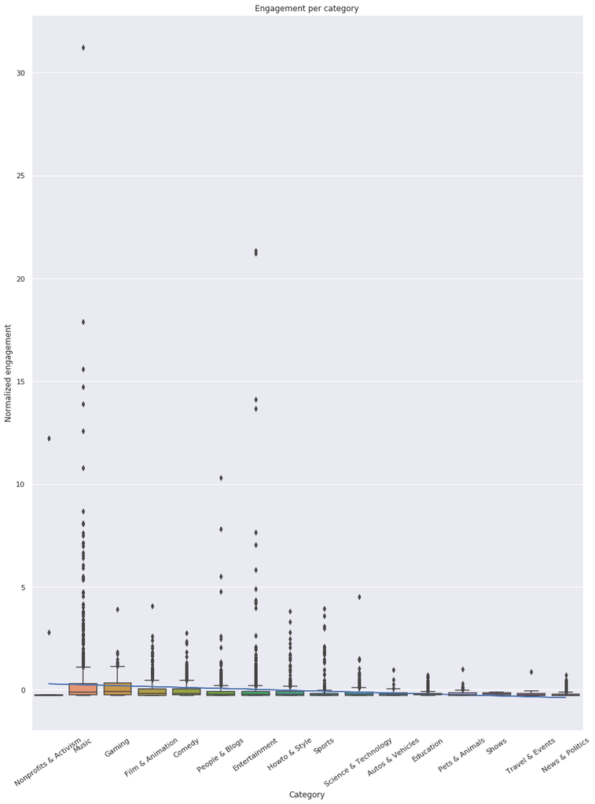

```python
# Plot it
plt.pyplot.figure(figsize=(15,20))
plot3 = sns.boxplot(x=yt_df['category_id'], y=yt_df['engagement_score'], order = yt_df.groupby('category_id').mean().sort_values('engagement_score', ascending=False).index)
plot3.set_xticklabels([categories[int(s.get_text())] for s in plot3.get_xticklabels()], rotation=35);
plot3.set(title='Engagement per category', xlabel='Category', ylabel='Normalized engagement')
plot3.plot(yt_df['sorted_category_id'], (yt_df['sorted_category_id'] * reg.coef_[0]) + reg.intercept_);
```

The Nonprofits & Activism category is a really interesting outlier - it has very few overall videos, but because of that ranks highest in average engagement because the videos it does have seem to have high engagement.

Another point of interest on the graph is that music seems to have the highest overall engagement, despite being second in amount of videos. It also has a lot of outliers with insanely high engagement. Entertainment fell many spots, but still has respectable outliers.

The regression line appears to show a relationship between category and engagement, but how statistically significant is it?

```python
# Use statsmodels to re-fit our line and do analysis
X = yt_df.loc[:, ['sorted_category_id']]
y = yt_df['engagement_score']

X = sm.add_constant(X)
model = sm.OLS(y, X)
res = model.fit()
res.summary()
```

OLS Regression Results

| Dep. Variable: | engagement_score | R-squared: | 0.028 |
| --- | --- | --- | --- |
| Model: | OLS | Adj. R-squared: | 0.028 |
| Method: | Least Squares | F-statistic: | 184.9 |
| Date: | Sat, 15 Dec 2018 | Prob (F-statistic): | 1.60e-41 |
| Time: | 17:31:31 | Log-Likelihood: | -8920.0 |
| No. Observations: | 6351 | AIC: | 1.784e+04 |
| Df Residuals: | 6349 | BIC: | 1.786e+04 |
| Df Model: | 1 |  |  |
| Covariance Type: | nonrobust |  |  |

|  | coef | std err | t | P>\|t\| | [0.025 | 0.975] |
| --- | --- | --- | --- | --- | --- | --- |
| const | 0.2903 | 0.025 | 11.765 | 0.000 | 0.242 | 0.339 |
| sorted_category_id | -0.0448 | 0.003 | -13.596 | 0.000 | -0.051 | -0.038 |

| Omnibus: | 11821.847 | Durbin-Watson: | 1.909 |
| --- | --- | --- | --- |
| Prob(Omnibus): | 0.000 | Jarque-Bera (JB): | 22580492.367 |
| Skew: | 13.928 | Prob(JB): | 0.00 |
| Kurtosis: | 293.782 | Cond. No. | 15.1 |

Warnings:  
[1] Standard Errors assume that the covariance matrix of the errors is correctly specified.

The coeffecients for the regression match, which means we're dealing with the same line as before. Taking a look at some of the various statistics that statsmodels gives us, we can quickly conclude that because the p value is zero, we can reject the null hypothesis.

So, we can conclude that there is a correlation between category and user engagement.

# Conclusion

First, we looked at how people react to trending videos. In general, they get a lot of views, with some being breakaway hits. Looking at likes and dislikes, most trending videos have a high like-to-dislike ratio, but some actually have more dislikes than likes.

Then, we looked at data about the videos themselves - what are the categories? The tags? Entertainment and music both tended to be very represented in trending, while for tags humor was the most frequent.

Then, we defined a metric of user engagement and asked if there was a correlation between engagement and category. After doing a linear regression, we found a very significant relationship.

For content creators and advertisers, this is huge. Both parties benefit from involving themselves in these high-engagement categories, and likely do data science similar to this.

# Additional Resources

There's so much more than can be done in this space, as long as the data is out there. This analysis focused on metadata, rather than on the actual content of the videos themselves. While we don't have full data on that, official datasets like [youtube8m](https://research.google.com/youtube8m/) are a fantastic start to bring the actual content into the fold in an automated way.

There's also a lot of other analysis that could be done, given the data we have. Do some channels trend more than others? Can we use the titles and descriptions in a meaningful way, perhaps with NLP? If we weight other statistics using views, does our analysis change?